# Introduction_4_process_pgxseg

Hangjia Zhao

2023-08-23

# Load library

```r
library(pgxRpi)
```

## `pgxSegprocess` function

This function extracts segments, CNV frequency, and metadata from local “pgxseg” files and supports survival data visualization

- `file` A string specifying the path and name of the “pgxseg” file where the data is to be read.
- `group_id` A string specifying which id is used for grouping in KM plot or CNV frequency calculation. Default is “group_id”.
- `show_KM_plot` A logical value determining whether to return the Kaplan-Meier plot based on metadata. Default is FALSE.
- `return_metadata` A logical value determining whether to return metadata. Default is FALSE.
- `return_seg` A logical value determining whether to return segment data. Default is FALSE.
- `return_frequency` A logical value determining whether to return CNV frequency data. The frequency calculation is based on segments in segment data and specified group id in metadata. Default is FALSE.
- `assembly` A string specifying which genome assembly version should be applied to CNV frequency calculation and plotting. Allowed options are “hg19”, “hg38”. Default is “hg38”.
- `...` Other parameters relevant to KM plot. These include `pval`, `pval.coord`, `pval.method`, `conf.int`, `linetype`, and `palette` (see ggsurvplot from survminer)

# Extract segment data

```r
# specify the location of file
file_name <- system.file("extdata", "example.pgxseg",package = 'pgxRpi')

# extract segment data
seg <- pgxSegprocess(file=file_name,return_seg = T)
```

The segment data looks like this

```r
head(seg)
```

```
#>   biosample_id reference_name    start       end  log2 variant_type
#> 1 GIST-gun-079             14 17200000 107043718 -1.00          DEL
#> 2 GIST-gun-080              3        0  90900000 -1.00          DEL
#> 3 GIST-gun-080              4 50000000 190214555 -1.00          DEL
#> 4 GIST-gun-080              5        0  48800000  1.32          DUP
#> 5 GIST-gun-080              5 48800000 181538259 -1.00          DEL
#> 6 GIST-gun-080              8        0  45200000 -1.00          DEL
#>   reference_bases alternate_bases
#> 1            None            None
#> 2            None            None
#> 3            None            None
#> 4            None            None
#> 5            None            None
#> 6            None            None
```

# Extract metadata

```r
meta <- pgxSegprocess(file=file_name,return_metadata = T)
```

The metadata looks like this

```r
head(meta)
```

```
#>   biosample_id histological_diagnosis_id histological_diagnosis_label
#> 1 GIST-gun-079               NCIT:C27243                  NCIT:C27243
#> 2 GIST-gun-080               NCIT:C27243                  NCIT:C27243
#> 3 GIST-gun-081               NCIT:C27243                  NCIT:C27243
#> 4 GIST-gun-082               NCIT:C27243                  NCIT:C27243
#> 5 GIST-gun-083               NCIT:C27243                  NCIT:C27243
#> 6 GIST-gun-084               NCIT:C27243                  NCIT:C27243
#>   icdo_morphology_id                     icdo_morphology_label        group_id
#> 1    pgx:icdom-89363 Gastrointestinal stromal tumor, malignant pgx:icdot-C16.9
#> 2    pgx:icdom-89363 Gastrointestinal stromal tumor, malignant pgx:icdot-C16.9
#> 3    pgx:icdom-89363 Gastrointestinal stromal tumor, malignant pgx:icdot-C16.9
#> 4    pgx:icdom-89363 Gastrointestinal stromal tumor, malignant pgx:icdot-C16.9
#> 5    pgx:icdom-89363 Gastrointestinal stromal tumor, malignant pgx:icdot-C16.9
#> 6    pgx:icdom-89363 Gastrointestinal stromal tumor, malignant pgx:icdot-C16.9
#>   icdo_topography_id group_label icdo_topography_label sampled_tissue_id
```

[output cut: 20 more lines]

# Visualize survival data in metadata

The KM plot is plotted from samples with available followup state and followup time. The default grouping is “group_id” column in metadata.

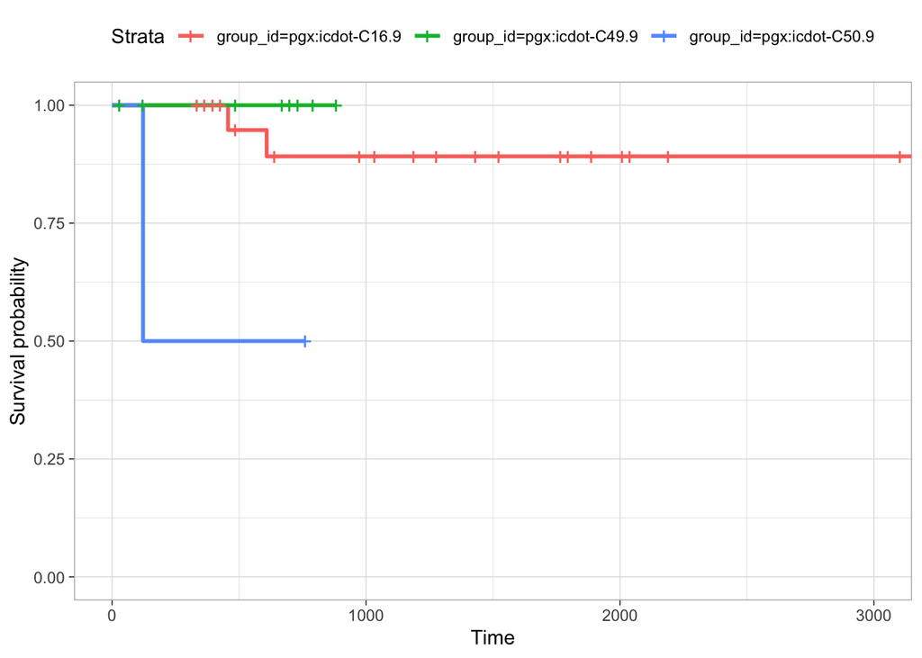

```r
pgxSegprocess(file=file_name,show_KM_plot = T)
```

You can try different grouping by `group_id` parameter

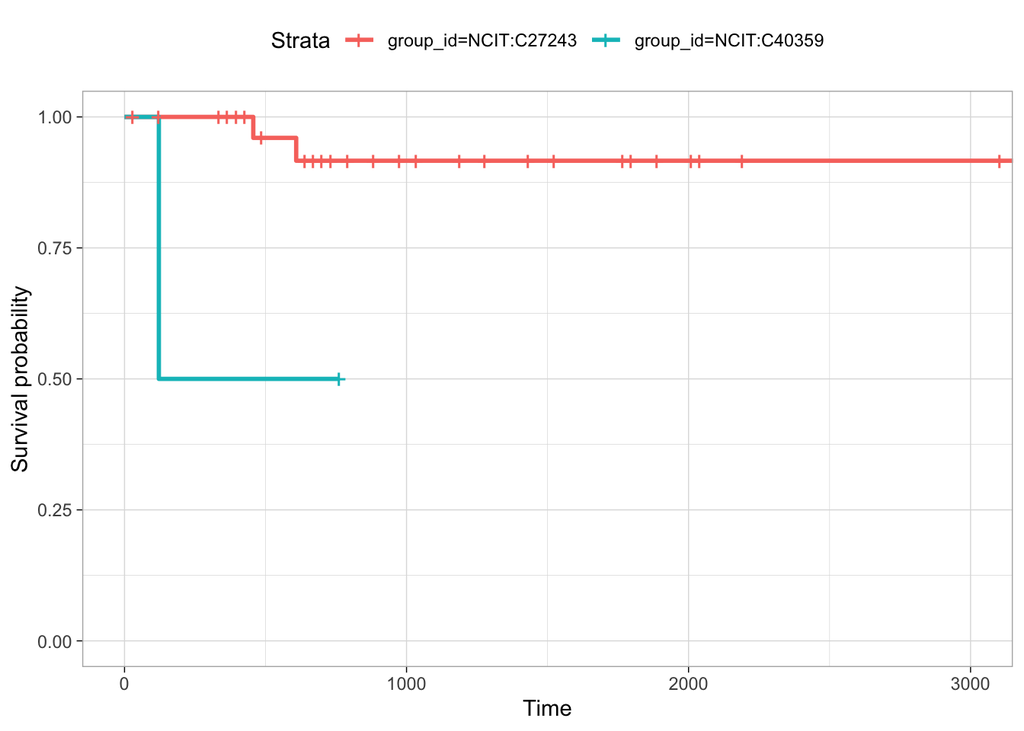

```r
pgxSegprocess(file=file_name,show_KM_plot = T,group_id = 'histological_diagnosis_id')
```

You can specify more parameters to modify this plot (see parameter `...` in documentation)

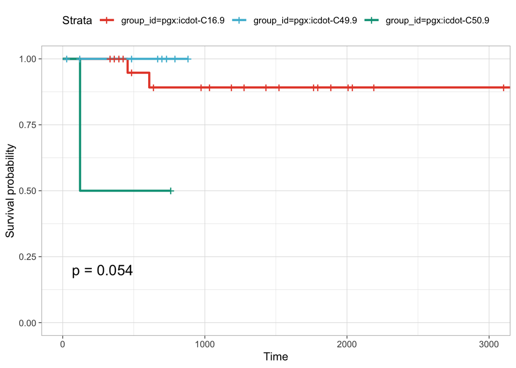

```r
pgxSegprocess(file=file_name,show_KM_plot = T,pval=T,palette='npg')
```

# Calculate CNV frequency

The CNV frequency is calculated from segments of samples with the same group_id. The group_id is specified in `group_id` parameter.

```r
# Default is "group_id" in metadata
frequency <- pgxSegprocess(file=file_name,return_frequency = T)
# Use different ids for grouping
frequency_2 <- pgxSegprocess(file=file_name,return_frequency = T,
                             group_id ='icdo_morphology_id')
```

The returned object is same as the CNV frequency object with “pgxfreq” format returned by `pgxLoader` function (format details see the vignette [Introduction_3_loadfrequency](https://htmlpreview.github.io/?https://github.com/progenetix/pgxRpi/blob/main/vignettes/Introduction_3_loadfrequency.html). It contains two slots ‘meta’ and ‘data’.

The ‘meta’ slot looks like this

```r
frequency$meta
```

```
#>          group_id                     group_label sample_count
#> 1 pgx:icdot-C16.9                         stomach           28
#> 2 pgx:icdot-C73.9                   thyroid gland            6
#> 3 pgx:icdot-C50.9                          breast            2
#> 4 pgx:icdot-C49.9 connective and soft tissue, NOS            7
#> 5           total                                           43
```

```r
frequency_2$meta
```

```
#>          group_id                               group_label sample_count
#> 1 pgx:icdom-89363 Gastrointestinal stromal tumor, malignant           35
#> 2 pgx:icdom-83353                      Follicular carcinoma            6
#> 3 pgx:icdom-80753     Squamous cell carcinoma, acantholytic            2
#> 4           total                                                     43
```

The ‘data’ slot includes CNV frequency matrices of all groups which exist in both metadata and segment data. It is noted that not all groups in metadata must exist in segment data (e.g. some samples don’t have CNV calls).

```r
names(frequency$data)
```

```
#> [1] "pgx:icdot-C16.9" "pgx:icdot-C73.9" "pgx:icdot-C50.9" "pgx:icdot-C49.9"
#> [5] "total"
```

```r
names(frequency_2$data)
```

```
#> [1] "pgx:icdom-89363" "pgx:icdom-83353" "pgx:icdom-80753" "total"
```

The ‘total’ data is concatenated CNV matrices across all groups. The individual matrix looks like this

```r
head(frequency$data$`pgx:icdot-C16.9`)
```

```
#>          group_id chromosome   start     end gain_frequency loss_frequency
#> 1 pgx:icdot-C16.9          1       0  400000              0       28.57143
#> 2 pgx:icdot-C16.9          1  400000 1400000              0       28.57143
#> 3 pgx:icdot-C16.9          1 1400000 2400000              0       28.57143
#> 4 pgx:icdot-C16.9          1 2400000 3400000              0       28.57143
#> 5 pgx:icdot-C16.9          1 3400000 4400000              0       28.57143
#> 6 pgx:icdot-C16.9          1 4400000 5400000              0       28.57143
```

In this matirx, `gain_frequency` and `loss_frequency` indicate the percentage (%) of samples from the corresponding group_id for gains and losses overlapping the genomic interval, respectively.

## Visualize CNV frequency

You can visualize the CNV frequency of the interesting group.

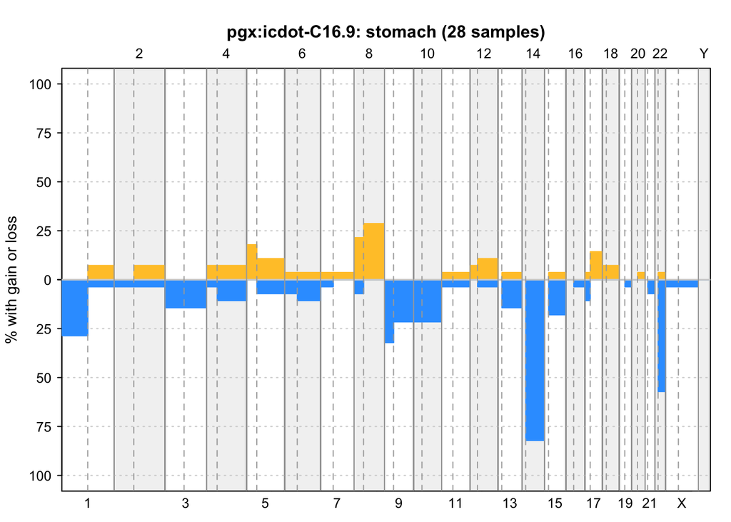

```r
pgxFreqplot(frequency, filters="pgx:icdot-C16.9")
```

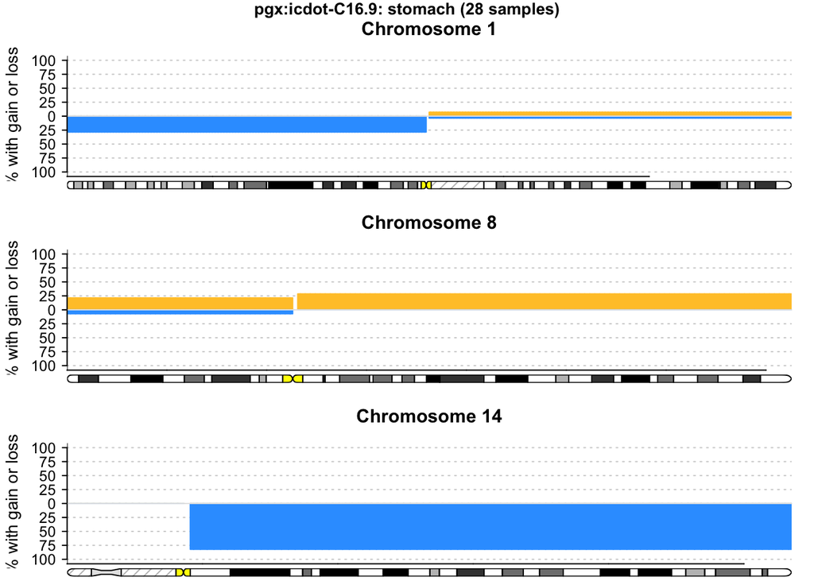

```r
pgxFreqplot(frequency, filters="pgx:icdot-C16.9",chrom = c(1,8,14), layout = c(3,1))
```

Circos plot supports multiple group visualization

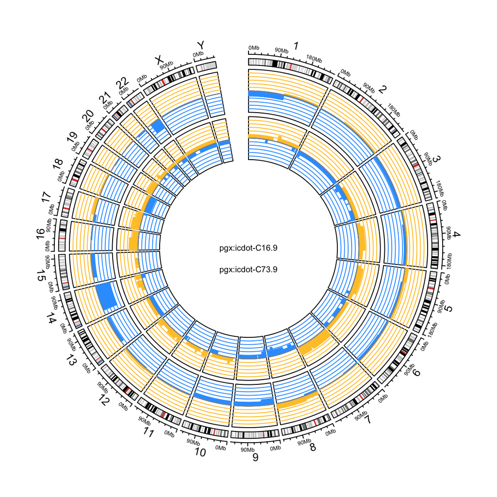

```r
pgxFreqplot(frequency, filters=c("pgx:icdot-C16.9","pgx:icdot-C73.9"),circos = T)
```

The details of `pgxFreqplot` function see the vignette [Introduction_3_loadfrequency](https://htmlpreview.github.io/?https://github.com/progenetix/pgxRpi/blob/main/vignettes/Introduction_3_loadfrequency.html).

# Extract all data

If you want different types of data such as segment data and metadata, and visualize the survival data at the same time, you can just set the corresponding parameters as TRUE. The returned data is an object including all specified data. It is noted that in this case the CNV frequency and KM plot use the same group_id.

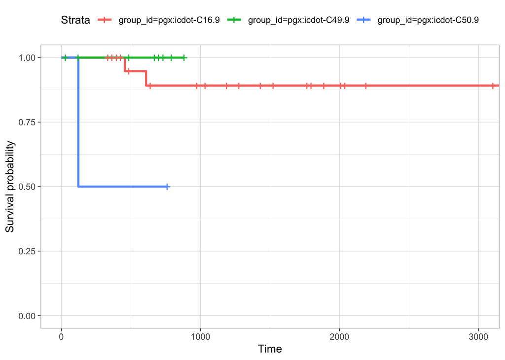

```r
info <- pgxSegprocess(file=file_name,show_KM_plot = T, return_seg = T,
                      return_metadata = T, return_frequency = T)
```

```r
names(info)
```

```
#> [1] "seg"       "meta"      "frequency"
```